# SecularDeathSim

Shawn Garbett

April 3, 2017

## The Problem

DES supports drawing from any observed distribution via sample to create patients. Modeling via differential equations requires a function. Since current simulations are using the observed data for establishment of a medical home. To convert this into a secular mortality probability that is a function of time for the simulation takes some effort.

## The data

The raw distributions taken from the Vanderbilt data sets, which was used for the PREDICT algorithm are as follows:

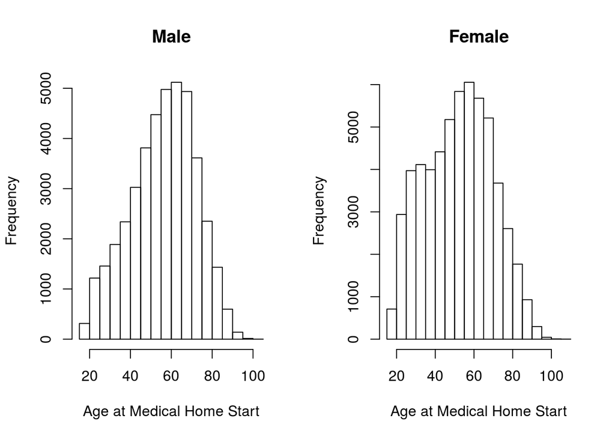

## Strategy

Each individual’s expected survival from social security can be overlaid into an array and this be used as the distribution of rates. We begin by fitting a spline to the 2011 social security data representing percent chance of death.

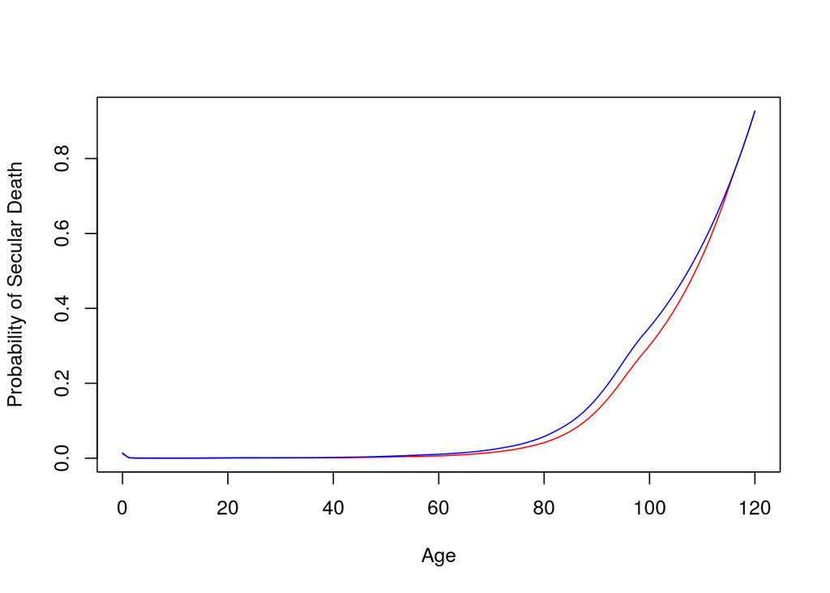

The observed Vanderbilt’s population’s predicted rate of death post establishment of medical home is thus found to be the following:

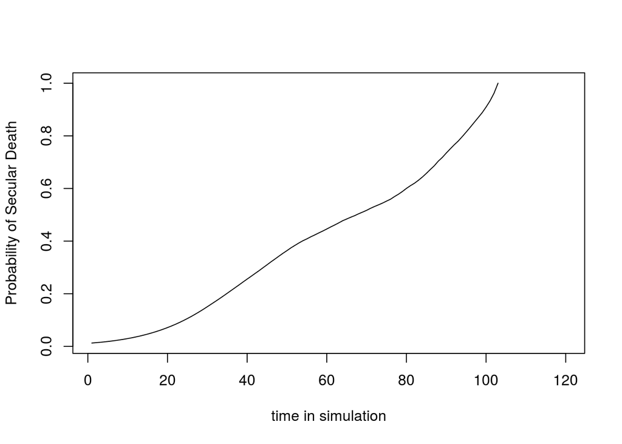

Since our simulations are focused on a 10 year time span. All that is required is the first 10 years. The red dashed line is a simple exponential model fit to the first 10 years.

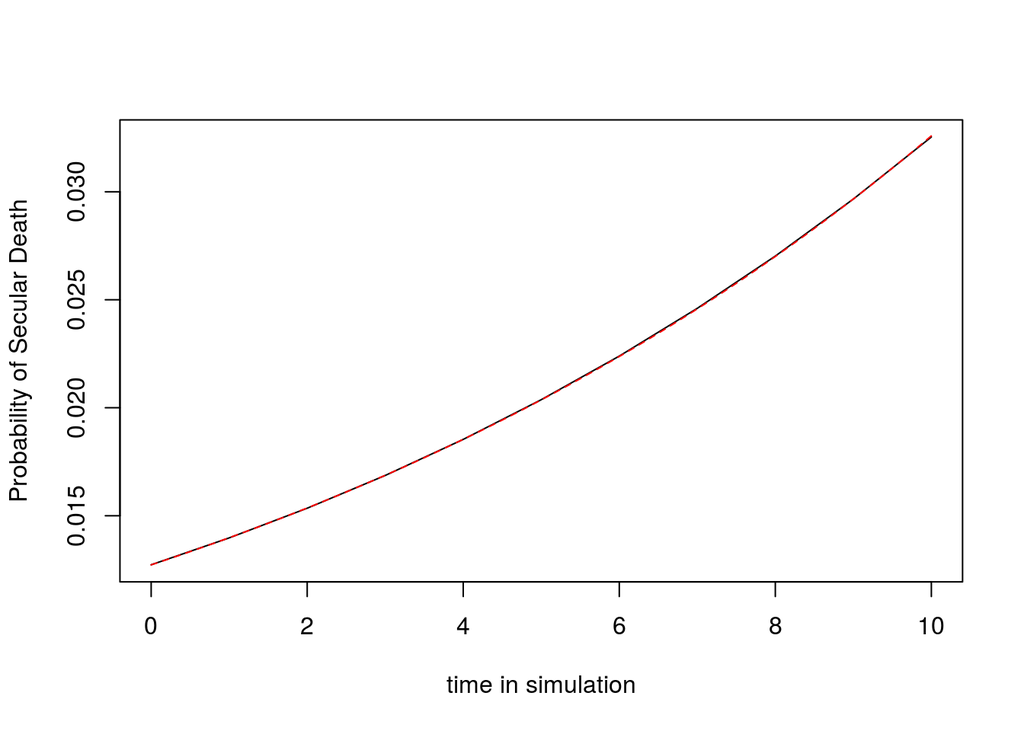

```r
plot(0:10, bins[1:11], typ='l', xlab="time in simulation", ylab="Probability of Secular Death")

model <- lm(log(Y) ~ X, data.frame(Y=bins[1:11], X=0:10))

fit <- model$coefficients

curve(exp(fit[1])*exp(fit[2]*x), col='red', lty=2, add=TRUE)
```

```r
fit
```

```
## (Intercept)           X
##  -4.3640902   0.0940359
```